# Intro to R: Classes 3 and 4 - Exploring Datasets

Dr Mark Grabowski

### 1. Getting data into R.

Now lets get some data in and start fooling with it. We will use the data set Sir Ronald Fisher used in coming up with a lot of classic statistical tests, the Iris Data set, which includes measurements on flowers for three different types of irises, and is a standard for starting multivariate stats analyses. Type:

```r
#iris.data<-read.csv(file.choose(),header=T)
iris.data<-read.csv("/Users/markgrabowski/Documents/Academic/Classes Taught/LJMU Classes/2021/Spring/7107NATSCI - R Classes/Online R Classes/Classes 3 and 4/Data/Iris_Data_Set.csv",header=T)
```

Now find the file we will be using for this session and load it into R.

Note that the file is saved in the ”.csv” format, which is probably the easiest way to get data into R, but you could do tab delimited also. If your data is in Excel you can save the files into these formats before pulling the data into R. You can also load a package designed to read in Excel files:

```r
#install.packages("readxl")
#library(readxl)
#theData <- read_excel("NAME OF FILE")
```

Note that all missing values in R must be entered as NA - usually my workflow is getting the data ready for R in a spreadsheet program like Excel, during which I replace all the missing values with NA. If NA is missing, R will have a difficult time reading the data into the program. It may read in integer data as factors, or characters.

Now type ”iris.data” and you can see the data. If you want to see only a portion of it (usually a good idea with large data sets), type

```r
iris.data[1:10,]
```

```
##    Species Sepal.length Sepal.width Petal.length Petal.width
## 1   I. set          5.1         3.5          1.4         0.2
## 2   I. set          4.9         3.0          1.4         0.2
## 3   I. set          4.7         3.2          1.3         0.2
## 4   I. set          4.6         3.1          1.5         0.2
## 5   I. set          5.0         3.6          1.4         0.2
## 6   I. set          5.4         3.9          1.7         0.4
## 7   I. set          4.6         3.4          1.4         0.3
## 8   I. set          5.0         3.4          1.5         0.2
## 9   I. set          4.4         2.9          1.4         0.2
## 10  I. set          4.9         3.1          1.5         0.1
```

This displays only the first 10 rows of the data set and we can see the column headers. Note the format for the entries in the brackets is [row,column]. The 1:10 is the first 10 rows of the iris.data data set, and the ”,” means all columns. So if you were to type iris.data[,,] you would see the entire data set just like typing only iris.data.

So, you can reference one variable in particular from a data set by typing iris.data[1,2], which gives you the integer at row 1 column 2 in iris.data.

Lets look at the dimensions of the data frame using the dim() command. Note that for vectors, this command is length() as there is only one dimension.

```r
dim(iris.data)
```

```
## [1] 150   5
```

Let’s get the names of the columns:

```r
names(iris.data)
```

```
## [1] "Species"      "Sepal.length" "Sepal.width"  "Petal.length" "Petal.width"
```

Lets look at iris.data using the ls.str() command, which was discussed in the Bonus section of the previous class.

```r
ls.str(iris.data)
```

```
## Petal.length :  num [1:150] 1.4 1.4 1.3 1.5 1.4 1.7 1.4 1.5 1.4 1.5 ...
## Petal.width :  num [1:150] 0.2 0.2 0.2 0.2 0.2 0.4 0.3 0.2 0.2 0.1 ...
## Sepal.length :  num [1:150] 5.1 4.9 4.7 4.6 5 5.4 4.6 5 4.4 4.9 ...
## Sepal.width :  num [1:150] 3.5 3 3.2 3.1 3.6 3.9 3.4 3.4 2.9 3.1 ...
## Species :  chr [1:150] "I. set" "I. set" "I. set" "I. set" "I. set" "I. set" "I. set" ...
```

If we want to know the breakdown of something like the number of individuals in each species we can use the table() function like so:

```r
table(iris.data$Species)
```

```
##
## I. set   I. v   I.vg
##     50     50     50
```

You can change the ”Species” part to the other names to see things like how many different measurements are in the column ”Sepal.length”.

```r
table(iris.data$Sepal.length)
```

```
##
## 4.3 4.4 4.5 4.6 4.7 4.8 4.9   5 5.1 5.2 5.3 5.4 5.5 5.6 5.7 5.8 5.9   6 6.1 6.2
##   1   3   1   4   2   5   6  10   9   4   1   6   7   6   8   7   3   6   6   4
## 6.3 6.4 6.5 6.6 6.7 6.8 6.9   7 7.1 7.2 7.3 7.4 7.6 7.7 7.9
##   9   7   5   2   8   3   4   1   1   3   1   1   1   4   1
```

Now lets look at one column of data individually. One way this is done is by using the ”$” to refer to the column of interest. Lets look at the data in the ”Petal.length” column:

```r
iris.data$Petal.length
```

```
##   [1] 1.4 1.4 1.3 1.5 1.4 1.7 1.4 1.5 1.4 1.5 1.5 1.6 1.4 1.1 1.2 1.5 1.3 1.4
##  [19] 1.7 1.5 1.7 1.5 1.0 1.7 1.9 1.6 1.6 1.5 1.4 1.6 1.6 1.5 1.5 1.4 1.5 1.2
##  [37] 1.3 1.4 1.3 1.5 1.3 1.3 1.3 1.6 1.9 1.4 1.6 1.4 1.5 1.4 4.7 4.5 4.9 4.0
##  [55] 4.6 4.5 4.7 3.3 4.6 3.9 3.5 4.2 4.0 4.7 3.6 4.4 4.5 4.1 4.5 3.9 4.8 4.0
##  [73] 4.9 4.7 4.3 4.4 4.8 5.0 4.5 3.5 3.8 3.7 3.9 5.1 4.5 4.5 4.7 4.4 4.1 4.0
##  [91] 4.4 4.6 4.0 3.3 4.2 4.2 4.2 4.3 3.0 4.1 6.0 5.1 5.9 5.6 5.8 6.6 4.5 6.3
## [109] 5.8 6.1 5.1 5.3 5.5 5.0 5.1 5.3 5.5 6.7 6.9 5.0 5.7 4.9 6.7 4.9 5.7 6.0
## [127] 4.8 4.9 5.6 5.8 6.1 6.4 5.6 5.1 5.6 6.1 5.6 5.5 4.8 5.4 5.6 5.1 5.1 5.9
## [145] 5.7 5.2 5.0 5.2 5.4 5.1
```

Or

```r
iris.data["Petal.length"]
```

```
##     Petal.length
## 1            1.4
## 2            1.4
## 3            1.3
## 4            1.5
## 5            1.4
## 6            1.7
## 7            1.4
## 8            1.5
## 9            1.4
## 10           1.5
## 11           1.5
## 12           1.6
## 13           1.4
## 14           1.1
```

[output cut: 136 more lines]

Or two at once, which is easiest to do by accessing the columns by their numbers rather than their names:

```r
iris.data[,2:3]
```

```
##     Sepal.length Sepal.width
## 1            5.1         3.5
## 2            4.9         3.0
## 3            4.7         3.2
## 4            4.6         3.1
## 5            5.0         3.6
## 6            5.4         3.9
## 7            4.6         3.4
## 8            5.0         3.4
## 9            4.4         2.9
## 10           4.9         3.1
## 11           5.4         3.7
## 12           4.8         3.4
## 13           4.8         3.0
## 14           4.3         3.0
```

[output cut: 136 more lines]

Or

```r
iris.data[c("Petal.length","Petal.width")]
```

```
##     Petal.length Petal.width
## 1            1.4         0.2
## 2            1.4         0.2
## 3            1.3         0.2
## 4            1.5         0.2
## 5            1.4         0.2
## 6            1.7         0.4
## 7            1.4         0.3
## 8            1.5         0.2
## 9            1.4         0.2
## 10           1.5         0.1
## 11           1.5         0.2
## 12           1.6         0.2
## 13           1.4         0.1
## 14           1.1         0.1
```

[output cut: 136 more lines]

Yup, exciting huh?

Finally we can get data out of R using the write.table() command like so:

```r
write.table(iris.data,"iris.data.csv",sep=",",row.names=F)
```

This will write the same file as we read in, but usually you will have done some manipulation to the data. Go to the ”Misc” menu at the top of the screen and click on ”Get Working Directory” to determine where R saved the file. You can also set the directory to where ever you would like.

### ACTIVITY 1.

Take columns 2 and 3 of the iris data set, add them together, and store in the variable x. Then take the sum of square root of the elements. Save this in y, and multiply by the variables Sepal.width. Display the output.

### Exploring your data.

Now that we have a multivariate data set in R, lets play around. To calculate column means, we need to make sure we are looking at the columns with numeric values in them (2-5). To do this type:

```r
colMeans(iris.data[,2:5])
```

```
## Sepal.length  Sepal.width Petal.length  Petal.width
##     5.843333     3.057333     3.758000     1.199333
```

For standard deviations of each column, we will use the apply() function, which in this case applies another function to a data frame. In this case we want to do it by columns. The code is below:

```r
apply(iris.data[,2:5],2,sd)
```

```
## Sepal.length  Sepal.width Petal.length  Petal.width
##    0.8280661    0.4358663    1.7652982    0.7622377
```

Here we are applying the function sd (to calculate standard deviations) to the data frame iris.data over columns, which is denoted by the 2, over rows would be 1. You find this from the very helpful help file for the apply function, which you can access using apply. You need to do this because otherwise the sd() function does not know how to read the data (by columns or rows).

### Data Exploration - following Zuur et al. (2010).

Lets run through some of the more common methods of data exploration to do before beginning the actual analysis following the data exploration setup of Zurr et al. (2010).

#### 1. Check for outliers in Y&X.

One way to do this is to look at box plots.

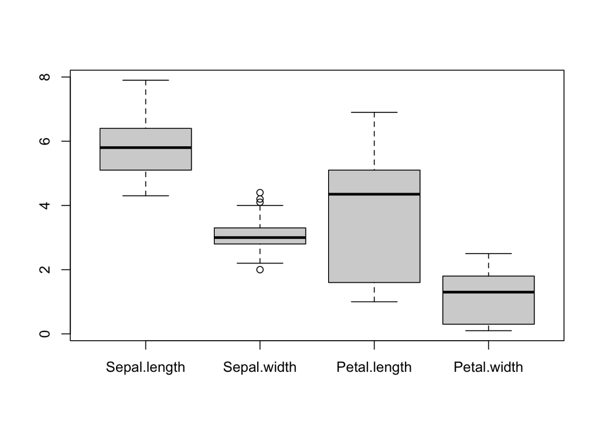

```r
boxplot(iris.data[,2:5])
```

This is pretty self-evident. The median is presented as the middle line, then the top and bottoms of the box are the 25% and 75% quartiles and the box contains half the observations. The lines, known as whiskers that extend out from the box show you 1.5 IQR or 1.5 times the distance between the upper and lower quartiles. Circles outside this range are outliers. This data set has three species of plants (found in the first column). We can also break it up so we are looking at the differences in one column, for example Petal.width by species. The tilda is used in equations in R to denote an = sign.

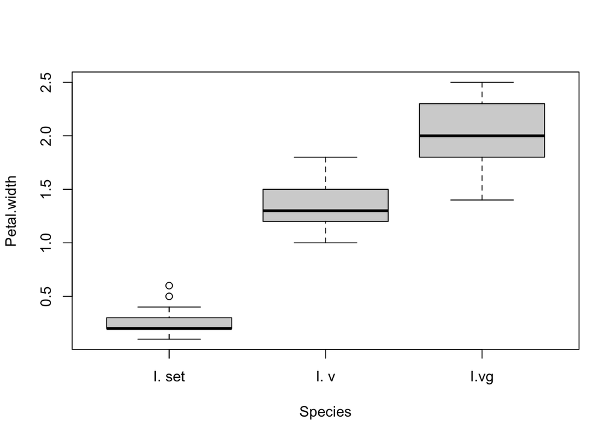

```r
boxplot(Petal.width~Species ,iris.data)
```

Another method of looking for outliers are Cleveland dotplots - they only work on each column individually, for reasons evident in a second:

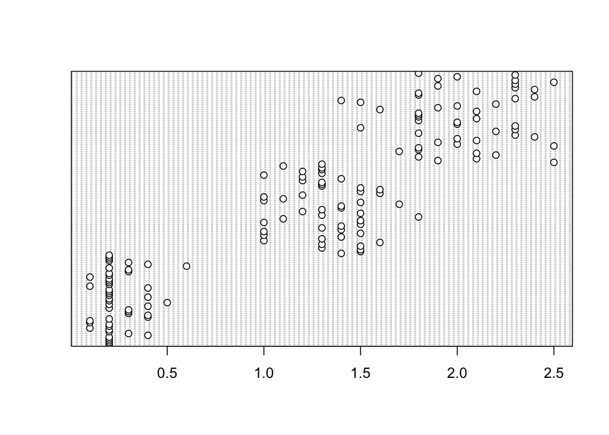

```r
dotchart(iris.data$Petal.width)
```

What this is showing you is values of the variables on the X and the order of the individual entries in the data set on the Y - the bottom of the plot is row 1 and the top row 150. Cleveland dotplots are great for looking for patterns in data - which would violate the assumptions of various statistical tests such as regression analysis. They can also show you outliers - solitary values to the left or right. Here the data is ordered by species in our data set, so the pattern we are looking at is the result of differences between the species.

#### 2. Homogeneity of variance.

Homogeneity of variance is an assumption of an ANOVA and other statistical tests. One way to test this is the Bartlett test.

```r
bartlett.test(iris.data[,3],iris.data$Species)
```

```
##
##  Bartlett test of homogeneity of variances
##
## data:  iris.data[, 3] and iris.data$Species
## Bartlett's K-squared = 2.0911, df = 2, p-value = 0.3515
```

This result is telling you that with a 0.05% probability of Type I error you can’t reject the null hypothesis of no differences between the variances.

#### 3. Are the data normally distributed?

A number of different statistical tests require the data be normally distributed (not regression though, which requires normality of the residuals)?

```r
shapiro.test(iris.data$Sepal.length)
```

```
##
##  Shapiro-Wilk normality test
##
## data:  iris.data$Sepal.length
## W = 0.97609, p-value = 0.01018
```

If we are using a 0.05 p-value for rejection of the null hypothesis, this suggests that the data is not normal, though this is combining different species once again.

```r
shapiro.test(iris.data[iris.data$Species=="I.vg",3])
```

```
##
##  Shapiro-Wilk normality test
##
## data:  iris.data[iris.data$Species == "I.vg", 3]
## W = 0.96739, p-value = 0.1809
```

Given the p-value we cannot reject the null hypotheses, so the data appears normal within one species individually.

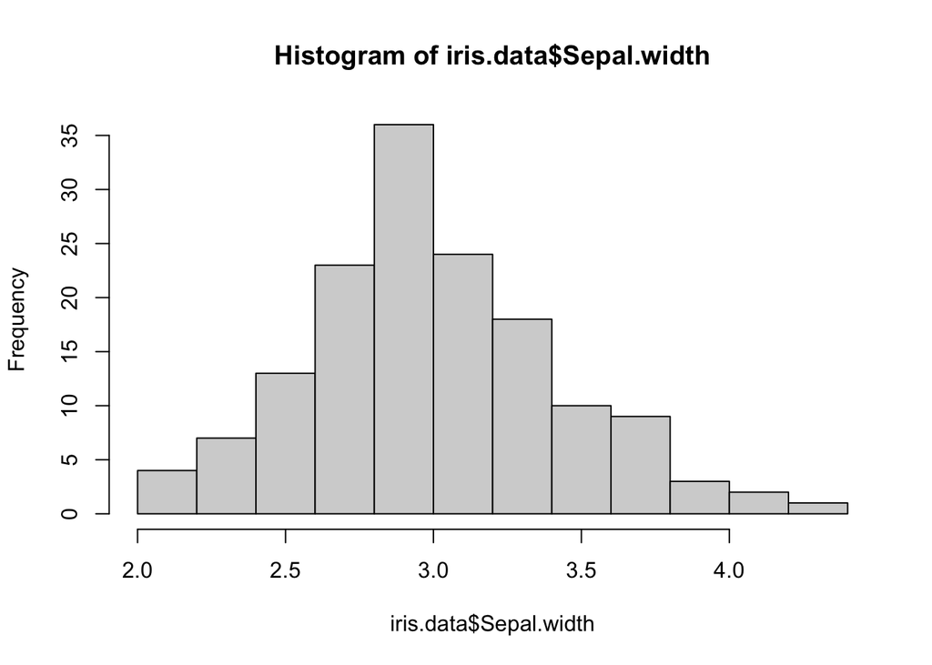

```r
hist(iris.data$Sepal.width)
```

One thing that is important to mention is that most functions, even ones that produce graphical output also produce a lot of results. These are in the ”Value” section of the help file. Check out ?hist. These can be accessed if the output of the function is assigned to a variable rather than simply running the code. These values are returned as a list.

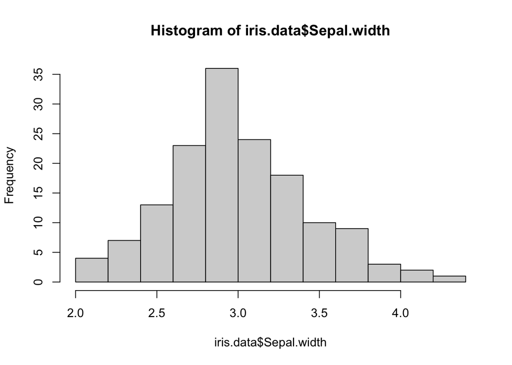

```r
test<-hist(iris.data$Sepal.width)
```

```r
test
```

```
## $breaks
##  [1] 2.0 2.2 2.4 2.6 2.8 3.0 3.2 3.4 3.6 3.8 4.0 4.2 4.4
##
## $counts
##  [1]  4  7 13 23 36 24 18 10  9  3  2  1
##
## $density
##  [1] 0.13333333 0.23333333 0.43333333 0.76666667 1.20000000 0.80000000
##  [7] 0.60000000 0.33333333 0.30000000 0.10000000 0.06666667 0.03333333
##
## $mids
##  [1] 2.1 2.3 2.5 2.7 2.9 3.1 3.3 3.5 3.7 3.9 4.1 4.3
##
## $xname
## [1] "iris.data$Sepal.width"
##
## $equidist
## [1] TRUE
##
## attr(,"class")
## [1] "histogram"
```

To directly access single values from the list you use the same format we used for columns of data.

```r
test$counts
```

```
##  [1]  4  7 13 23 36 24 18 10  9  3  2  1
```